# Targeted Perturb-Seq sensitively detects gene expression changes (Figure 2)

Schraivogel, Gschwind et al.

28/11/2019

This vignette reproduces the analysis in Figure 2 of Schraivogel, Gschwind, et al.

## Data

The following experiments were performed:

- We infected dCas9-KRAB-expressing K562 cells with a pool of lentiviruses carrying 56 gRNA sequences targeting one of 10 promoters from a selected region of chromosome 8, or 4 well-described enhancers, and 30 control gRNAs (Figure 2a).
- Cells were then analyzed by whole transcriptome 10x genomics, or alternatively by targeted readout. For targeting, we used a target gene panel containing the known promoter/enhancer target genes, and 60 presumably unrelated genes of similar expression level from the same region of chromosome 8.

The following data is required to reproduce these analysis:

```r
require(Matrix)

#Non-downsampled targeted seq data, 1.7Mb
TAP.nods <- readRDS(url("http://steinmetzlab.embl.de/TAPdata//TAP.nods.RDS"))
##this corresponds to the combination of ../data/TAP1/dge.txt and ../data/TAP2/dge.txt if the snakemake pipeline was run.

#Matrix encoding perturbation identity for targeted seq experiment, 173kb
TAP.per <-  t(readRDS(url("http://steinmetzlab.embl.de/TAPdata//TAP.per.RDS")))
##this corresponds to the combination of ../data/TAP1/dge.txt and ../data/TAP2/dge.txt if the snakemake pipeline was run.

#Non-downsampled whole transcriptome data, 272Mb
Whole.nods <-  readRDS(url("http://steinmetzlab.embl.de/TAPdata//Whole.nods.RDS"))

#Matrix encoding perturbation identity for whole transcriptome experiment, 289kb
Whole.per <- t(readRDS(url("http://steinmetzlab.embl.de/TAPdata//Whole.per.RDS")))
```

Data were downsampeld at the level of raw reads to realistically simulate a lower sequencing depth. All data processing steps can be reproduced by running the rule Figure2 of https://github.com/argschwind/tapseq_manuscript (documented there); alternatively we provide the results:

```bash
mkdir -p ../data/TAP1/downsampled
mkdir -p ../data/TAP2/downsampled
mkdir -p ../data/WholeTx/downsampled

#Downsampled targeted seq. data, 3.3 Mb
wget http://steinmetzlab.embl.de/TAPdata/TAP1.downsampled.zip
unzip -j -d ../data/TAP1/downsampled TAP1.downsampled.zip

wget http://steinmetzlab.embl.de/TAPdata/TAP2.downsampled.zip
unzip -j -d ../data/TAP2/downsampled TAP2.downsampled.zip

#Downsampled whole transcriptome seq. data, 750 Mb
wget http://steinmetzlab.embl.de/TAPdata/WholeTx.downsampled.zip
unzip -j -d ../data/WholeTx/downsampled WholeTx.downsampled.zip

rm TAP1.downsampled.zip TAP2.downsampled.zip WholeTx.downsampled.zip
```

Finally, data is re-sampled several times and differential expression testing is run. These results are expected to be available prior to running the remainder of this vignette; they can either be downloaded, or computed on a compute cluster with SLURM as job scheduler. Please run either option from the script below before running this vignette for the first time. This code will not be run automatically.

```bash
# Option 1: Download our result
mkdir runs

wget http://steinmetzlab.embl.de/TAPdata//002_DESampled_MAST.cov.wholegenome.zip
unzip -j -d runs/MAST.cov.wholegenome 002_DESampled_MAST.cov.wholegenome.zip
rm 002_DESampled_MAST.cov.wholegenome.zip

wget http://steinmetzlab.embl.de/TAPdata//002_DESampled_MAST.cov.targeted.zip
unzip -j -d runs/MAST.cov.targeted 002_DESampled_MAST.cov.targeted.zip
rm 002_DESampled_MAST.cov.targeted.zip

# Option 2: Compute results
#Please check the first lines of the following script to make sure all required R packages are available: functions/script_runDownsamplingTest.R

mkdir runs

#The following code submits all necessary jobs to slurm. Compute time is approximately 36h.
tempdir=/tmpdata/slurmapply
modules="module load R-bundle-Bioconductor-GBCS/3.7-foss-2017b-R-3.5.1" #Any code that slurm nodes need to run in order to have R available.

Rscript functions/scripts_DownsamplingWrapper.R $tempdir $modules
```

## Compute environment

We performed compute-expensive operations on a compute cluster with SLURM as job scheduler. In this script, there are three options:

```r
download <- T #simply download computation results; do not run compute-expensive tasks
slurm <- T # if download is set to F, use slurm as a job scheduler
slurm_tempdir <- "/scratch/velten/slurmapply" # a directory for data transferred between this R session and slurm jobs
slurm_modulecommand <- "module load R-bundle-Bioconductor-GBCS/3.7-foss-2017b-R-3.5.1"  #any code that each slurm node needs to run in order to be able to call the correct version of R
ncores <- 1 #if both slurm and download are set to F, perform computations locally with this many cores.


source("functions/slurmapply.R") #function for calling slurm from R. See below for usage.

if (!slurm ) slurmlapply <- function(X, FUN, ..., s.walltime = "1:00:00", s.memory = NULL, s.ncores = 1, s.tmpdir = "/scratch/velten/slurmapply", s.collect = TRUE, s.pckgs = getAttachedPackages(), s.module ="") {
  mclapply(X, FUN, ..., mc.cores = ncores)
}
```

Load required packages and functions.

```r
.libPaths("/g/steinmetz/velten/Software/RLibs-seurat3/")
require(Seurat)
require(MAST)
require(parallel)
require(reshape2)
require(plyr)
require(scales)
require(venneuler)
require(ROCR)
require(ggplot2)
```

## Simple differential expression test, no downsampling (Figure 2d,e)

Extract some metadata information:

```r
scramble.cols <- grep("non-targeting",colnames(TAP.per))
is.scramble <- apply(TAP.per[,scramble.cols],1,function(x) any(x > 0)) & apply(TAP.per[,-scramble.cols],1,function(x) all(x == 0)) # <<- CHECK!
TAP.nods <- TAP.nods[!grepl("CROPseq",rownames(TAP.nods)),]
cell.per.per <- apply(TAP.per,2,sum)
useper <- colnames(TAP.per)[!grepl("non-target", colnames(TAP.per))]

targetgenes <- unique(gsub("[_-].+","",colnames(TAP.per)))
targetgenes[targetgenes == "HS2"] <- "HBE1"
class <- targetgenes %in% c("ZFPM2","HBE1","GATA1","MYC")
ngenes <- apply(TAP.nods >0 , 2, sum)
```

Run differential expression tests, targeted seq.:

```r
source("functions/function_DEtest_basic.R")

if (download) {
  noDownsampling <- readRDS(url("http://steinmetzlab.embl.de/TAPdata//Figure2_DE_TAP.RDS"))
  }else {
noDownsampling <- slurmlapply(useper, runSeuratTest, DGE= TAP.nods,pert = TAP.per, covariate = ngenes, scrcols= scramble.cols, normfun = function(x) sum(x[x < quantile(x, probs = 0.9)]) + 1, s.walltime = "00:30:00", s.tmpdir = slurm_tempdir, s.module = slurm_modulecommand)
  noDownsampling <- do.call(rbind, noDownsampling)
}
```

Extract metadata information for Whole Tx and run differential expression tests. This is initially done for the target genes only.

```r
scramble.cols <- grep("non-targeting",colnames(Whole.per))
is.scramble <- apply(Whole.per[,scramble.cols],1,function(x) any(x > 0)) & apply(Whole.per[,-scramble.cols],1,function(x) all(x == 0))
Whole.nods.targetgenes <- Whole.nods[rownames(TAP.nods),]
Whole.nods <- Whole.nods[!grepl("CROP",rownames(Whole.nods)),]
useper <- colnames(Whole.per)[!grepl("non-target", colnames(Whole.per))]
  ngenes <- apply(Whole.nods >0 , 2, sum)

if (download) {
    noDownsampling.Whole.Targetgenes <- readRDS(url("http://steinmetzlab.embl.de/TAPdata//Figure2_DE_WholeTargets.RDS"))
} else {


noDownsampling.Whole.Targetgenes.Jobs <- slurmlapply(useper, runSeuratTest, DGE= Whole.nods.targetgenes,pert = Whole.per, covariate = ngenes, scrcols= scramble.cols, normfun = function(x) sum(x[x < quantile(x, probs = 0.9)]) + 1, s.walltime = "5:00:00", s.collect = F, s.tmpdir = slurm_tempdir, s.module = slurm_modulecommand)

#noDownsampling.Whole <- do.call(slurmcollect, noDownsampling.Whole.Jobs)
#noDownsampling.Whole <- do.call(rbind, noDownsampling.Whole)

noDownsampling.Whole.Targetgenes <- do.call(slurmcollect, noDownsampling.Whole.Targetgenes.Jobs)
noDownsampling.Whole.Targetgenes <- do.call(rbind, noDownsampling.Whole.Targetgenes)
}
```

After harmonizing the output and parsing some information (not shown, see raw Vignette code), we plot figure 2d:

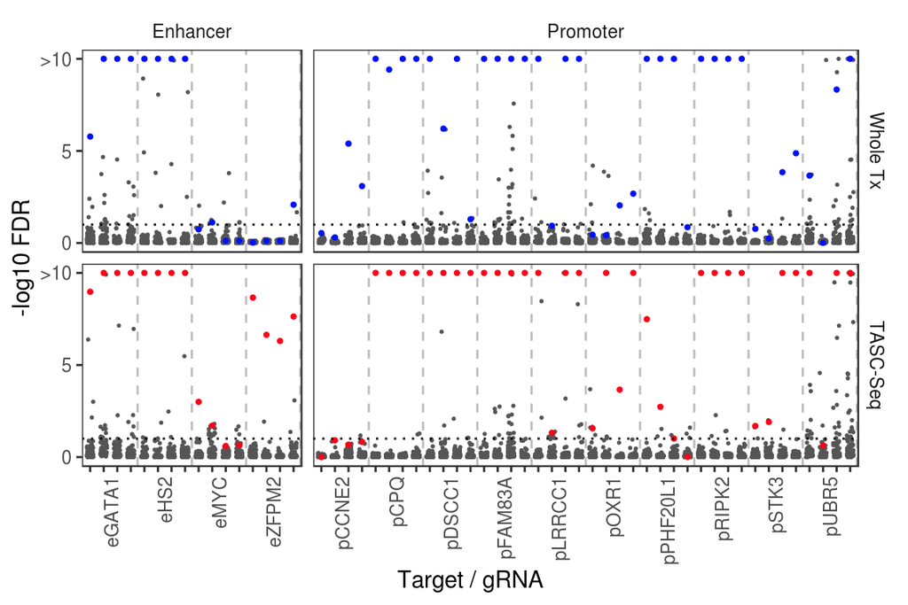

```r
ggplot(aes(x = guide , y = -log10(p_val_adj), color = paste0(assay,target == gene)), data=subset(noDownsampling.m, target!= gene)) +
  geom_point(position = position_jitter(0.25,0.1), size=0.3) +geom_point(data=subset(noDownsampling.m, target==gene), size = 0.75) +
  scale_y_continuous(limits=c(0,10), breaks = seq(0,10,by=5), labels = c(seq(0,5,by=5),">10"),oob=scales::squish) + theme_bw() +
  ylab("-log10 FDR") + xlab("Target / gRNA") + scale_color_manual(values = c("TASC-SeqFALSE" = "#555555", "TASC-SeqTRUE" = "#ff0018" ,"Whole TxFALSE" = "#555555", "Whole TxTRUE" = "#0012f9"),name="", labels = c("FALSE" = "Off-target", "TRUE" = "Intended hit"), guide=F) +
  theme( panel.grid = element_blank(), axis.text.x = element_text(angle=90, hjust=1), legend.position = "bottom", strip.background = element_rect(fill=NA,colour=NA) ) + facet_grid(assay~class, scales="free_x", space= "free_x") + scale_x_discrete(breaks = breaks, labels = uselabels) + geom_vline(xintercept = seq(4.5,56,by=4), color = "grey", linetype =2) + geom_hline(yintercept = 1, linetype=3)
```

Plot figure 2e (Venn diagram):

[figure not shown]

```r
#a venn diagram
noDownsampling$interaction <- paste(noDownsampling$guide, noDownsampling$gene)
noDownsampling.Whole.Targetgenes$interaction <- paste(noDownsampling.Whole.Targetgenes$guide, noDownsampling.Whole.Targetgenes$gene)

TAP.hits <- subset(noDownsampling, p_val_adj < 0.1)
Whole.hits <- subset(noDownsampling.Whole.Targetgenes, p_val_adj <.1)

TAP.hits.ontarget <- subset(TAP.hits, gene == target)
Whole.hits.ontarget <- subset(Whole.hits, gene == target)

TAP.hits.offtarget <- subset(TAP.hits, gene != target)
Whole.hits.offtarget <- subset(Whole.hits, gene != target)

vennvector <- c("Whole&TAP&OnTarget" = length(intersect(TAP.hits.ontarget$interaction, Whole.hits.ontarget$interaction)),
                "Whole&TAP" = 0)#length(intersect(TAP.hits.offtarget$interaction, Whole.hits.offtarget$interaction)))
vennvector <- c(vennvector, "Whole&OnTarget" = nrow(Whole.hits.ontarget) - unname(vennvector["Whole&TAP&OnTarget"]))
vennvector <- c(vennvector, "TAP&OnTarget" = nrow(TAP.hits.ontarget) - unname(vennvector["Whole&TAP&OnTarget"]))
vennvector <- c(vennvector, "TAP" = 0)#nrow(TAP.hits.offtarget) - unname(vennvector["Whole&TAP"]))
vennvector <- c(vennvector, "Whole" = 0)#nrow(Whole.hits.offtarget) - unname(vennvector["Whole&TAP"]))
vennvector <- c(vennvector, "OnTarget" = length(unique(noDownsampling$guide)) - unname(vennvector["Whole&TAP&OnTarget"]) - unname(vennvector["Whole&OnTarget"]) - unname(vennvector["TAP&OnTarget"]))
vennplot <- venneuler(vennvector)
plot(vennplot)
```

## Analysis of downsampling experiment by Precision-Recall Curves (Figure 2f,g)

Load results of differential expression testing following downsampling of cells and reads. See above for how these results are obtained. Then compute Precision-Recall curves.

```r
#now load the output from the big sampling experiment.
downsampled.tap.files <- list.files("runs/MAST.cov.targeted/",pattern = "TAP", full.names = T)
downsampled.tap <- lapply(downsampled.tap.files, readRDS)
downsampled.tap <- do.call(rbind, downsampled.tap)

downsampled.whole.files <- list.files("runs/MAST.cov.targeted/",pattern = "Whole", full.names = T)
downsampled.whole <- lapply(downsampled.whole.files, readRDS)
downsampled.whole <- do.call(rbind, downsampled.whole)

downsampled.wholegenome.files <- list.files("runs/MAST.cov.wholegenome/",pattern = "Whole", full.names = T)
downsampled.wholegenome <- lapply(downsampled.wholegenome.files, readRDS)
downsampled.wholegenome <- do.call(rbind, downsampled.wholegenome)

downsampled.tap$assay <- "TAP"
downsampled.whole$assay <- "WholeTx"
downsampled.wholegenome$assay <- "WholeGenome"

out <- rbind(downsampled.tap, downsampled.whole,downsampled.wholegenome )


out$target <- gsub("[-_].+","", out$guide)
out$target <- gsub("HS2","HBE1",out$target)

out$tp <- out$target == out$gene


getarea <- function(x, y) {
  dx <- x[-1] - x[-length(x)]
  ymean <- (y[-1] + y[-length(y)]) /2
  sum(dx * ymean, na.rm=T)
}

auprc.value <- ddply(out,  c("ncells","assay","reads"), function(x) {
  pred <- prediction(-log10(x$p_val), x$tp)
  auc <- performance(pred, "sens","prec")

  data.frame(auc = getarea(auc@y.values[[1]], auc@x.values[[1]]))
}, .progress = "text")

auprc <- ddply(out,  c("ncells","assay","reads"), function(x) {
  pred <- prediction(-log10(x$p_val), x$tp)
  auc <- performance(pred, "sens","prec")

  data.frame(prec = auc@x.values[[1]], sens = auc@y.values[[1]])
},.progress = "text")
```

Figure 2f: Sample curves

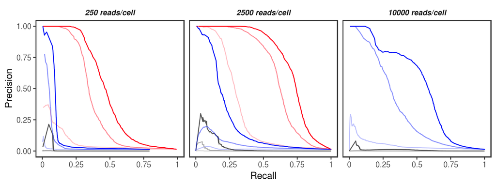

```r
toplot<-subset(auprc, ncells %in% c(10,50,150) &  reads %in% c(250,2500,10000) )
toplot<-toplot[sample(1:nrow(toplot), 1000000),]

qplot(x = sens, y = prec , color = assay,group = paste(ncells, assay), alpha =ncells, geom="line",data=toplot)  + facet_wrap(~factor(paste(reads,"reads/cell"), levels = paste(c(250,2500,10000),"reads/cell") )) + theme_bw()  + ylab ("Precision") + xlab("Recall") + scale_color_manual(name ="Method",values = c("TAP"= "#ff0018","WholeTx" = "#0012f9", "WholeGenome" = "#555555"), guide=F)  + scale_x_continuous(breaks = seq(0,1,by=0.25), labels = c("0","0.25","0.5","0.75","1")) + theme(panel.grid = element_blank(), strip.background = element_blank(), strip.text = element_text(face="bold.italic"), panel.border = element_rect(fill=NA,size=1)) + scale_alpha_continuous(limits=c(10,150),range=c(0.25,1), guide=F)
```

Figure 2g, left panel: Areas under the precision recall curves

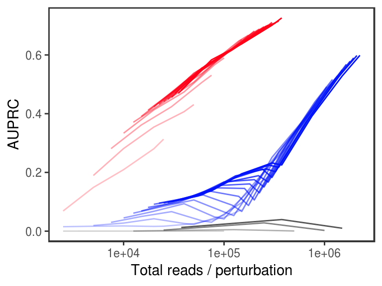

```r
mx <- rev(1:15); names(mx) <- as.character(10*1:15)
qplot(x = reads * ncells, y = auc , color =assay ,group = paste(ncells, assay), alpha =ncells, geom="line",data=auprc.value)+ ylab ("AUPRC") + xlab("Total reads / perturbation") + theme_bw()  + theme(legend.position = "bottom") + scale_x_log10()+  scale_color_manual(name ="Method",values = c("TAP"= "#ff0018","WholeTx" = "#0012f9", "WholeGenome" = "#555555"), guide=F) +  theme(panel.grid = element_blank(), panel.border = element_rect(fill=NA, size=1)) + scale_alpha_continuous(range = c(0.25,1),guide=F)
```

Figure 2g, Right panel: Fold difference in required read depth for a given AUPRC.

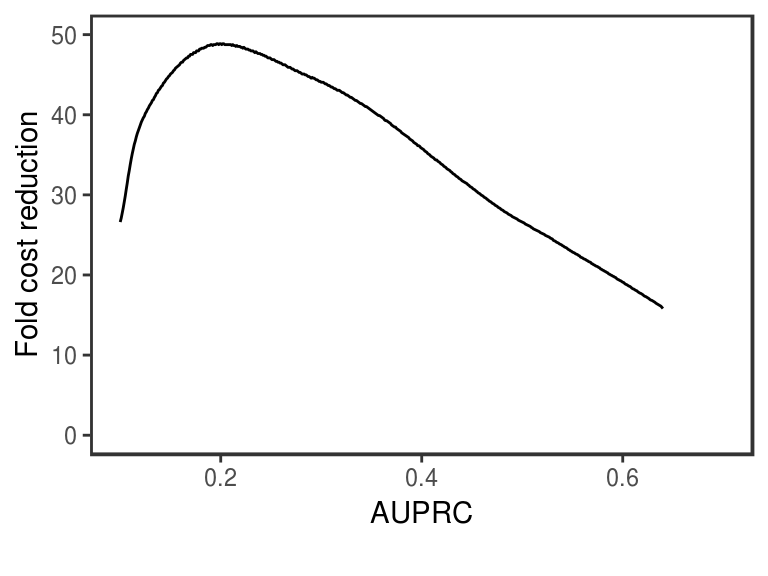

```r
roc.value <- auprc.value
roc.value$totalreads <- roc.value$reads * roc.value$ncells
fit.tap <- loess(auc ~ log10(totalreads), data= subset(roc.value,  assay == "TAP"))
fit.whole <- loess(auc ~ log10(totalreads), data= subset(roc.value,  assay == "WholeTx"))
range <- 10^seq(3,6.5,by=0.001)
lookup <- data.frame(reads = range,
                     sens.tap = predict(fit.tap, newdata = data.frame(totalreads = range)),
                     sens.whole = predict(fit.whole, newdata = data.frame(totalreads = range)))
lrange <- seq(0.1,0.7,by =0.001)
cost <-data.frame(sens = lrange,
                  reads.tap = sapply(lrange, function(x) if (min(abs(lookup$sens.tap - x),na.rm = T) < 0.002) lookup$reads[which.min(abs(lookup$sens.tap - x))] else NA),
                  reads.whole = sapply(lrange, function(x) if (min(abs(lookup$sens.whole - x),na.rm = T) < 0.002)  lookup$reads[which.min(abs(lookup$sens.whole - x))] else NA))
cost$savings <- cost$reads.whole / cost$reads.tap



qplot(x  = sens, y = savings, data= cost, geom="line") + xlab("AUPRC\n") + ylab("Fold cost reduction") + theme_bw() + scale_y_continuous(limits=c(0,50)) + theme(panel.grid = element_blank(),panel.border = element_rect(fill=NA, size=1))
```

For these analyses, we first compute the expression difference between perturbed and non-perturbed cells based on non-downsampled data.

```r
guide2target <- gsub("[-_].+","", useper)
guide2target <- gsub("HS2","HBE1",guide2target)
names(guide2target) <- useper


scramble.cols <- grep("non-targeting",colnames(Whole.per))
is.scramble <- apply(Whole.per[,scramble.cols],1,function(x) any(x > 0)) & apply(Whole.per[,-scramble.cols],1,function(x) all(x == 0))
useper <- colnames(Whole.per)[!grepl("non-target", colnames(Whole.per))]

downsampled <- rbind(downsampled.tap, downsampled.whole)

#to look at absolute difference, replace / by -
expdiff <- lapply(unique(guide2target), function(x) {
  y <- ifelse(any(grepl(x, names(guide2target))), x,"HS2")
  guide = as.character(unique(names(guide2target)[grepl(y, names(guide2target))]))
  r <- lapply(guide, function(g) mean(unlist(Whole.nods[x,Whole.per[,g]==1])) - mean(unlist(Whole.nods[x,is.scramble])))
  names(r) <- guide
  r
})
names(expdiff) <- unique(guide2target)

expdiff.rel <- lapply(unique(guide2target), function(x) {
  y <- ifelse(any(grepl(x, names(guide2target))), x,"HS2")
  guide = as.character(unique(names(guide2target)[grepl(y, names(guide2target))]))
  r <- lapply(guide, function(g) mean(unlist(Whole.nods[x,Whole.per[,g]==1])) / mean(unlist(Whole.nods[x,is.scramble])))
  names(r) <- guide
  r
})
names(expdiff.rel) <- unique(guide2target)
```

Then, we create data tables containing, for each guide RNA-target pair, information on the absolute and relative expression difference elicited by the gRNA across all cells. All data tables also contain the probability of identifying said expression difference in downsampled data.

These data tables are used to fit logistic regression. From the logistic regression fit, the molecular sensitivity is computed as the expression difference at which the probability of detection is 50%.

```r
modelfs.complete <- ddply(downsampled, c("test",  "ncells", "norm", "reads", "assay"), function(y) {
    x <- ddply(y, "guide", summarise, hits = paste(gene[p_val_adj < 0.1], collapse = ";"))
  t <- gsub("[-_].+","", x$guide)
  outs <- strsplit(as.character(x$hits), split = ";")
  modelf <- do.call(rbind,mapply(function(target, result, g) {
    if (target == "HS2") {
      target <- c("HBE1")
      ed <- sapply(target, function(tt) expdiff[[tt]][[g]])
      edr <-sapply(target, function(tt) expdiff.rel[[tt]][[g]])

    } else {
      ed <- expdiff[[target]][[g]]
      edr <- expdiff.rel[[target]][[g]]
    }

    data.frame(expr =log10(abs(ed)), expr.rel = abs(log2(edr)), hit = target %in% result, target=target, guide =g)
  }, t, outs, as.character(x$guide) ,SIMPLIFY = F))

}, .progress = "text")

modelfs <-   ddply(modelfs.complete, c("test",  "ncells", "norm","guide","target", "reads","assay"),summarise, hit = mean(hit), expr = mean(expr), expr.rel =mean(expr.rel))

glmodels <- ddply(modelfs.complete, c("test",  "ncells", "norm", "reads","assay"), function(modelf) {
  model <- glm(hit ~ expr, data=modelf, family = "binomial")
  data.frame(x = seq(min(modelf$expr), max(modelf$expr), length.out = 200),
             y = predict(model, type="response", newdata= data.frame(expr = seq(min(modelf$expr), max(modelf$expr), length.out = 200))),
             test = unique(modelf$test), ncells = unique(modelf$ncells), norm = unique(modelf$norm))
}, .progress = "text")

glmodels.rel <- ddply(subset(modelfs.complete, !is.infinite(expr.rel)), c("test",  "ncells", "norm", "reads","assay"), function(modelf) {
  model <- glm(hit ~ abs(log2(expr.rel)), data=modelf, family = "binomial")
  data.frame(x = seq(min(modelf$expr.rel), max(modelf$expr.rel), length.out = 200),
             y = predict(model, type="response", newdata= data.frame(expr.rel = seq(min(modelf$expr.rel), max(modelf$expr.rel), length.out = 200))),
             test = unique(modelf$test), ncells = unique(modelf$ncells), norm = unique(modelf$norm))
}, .progress = "text")


#identify the sensitivty
glm.singlenumber <- ddply(glmodels, c("test","norm","ncells","reads","assay"), summarise, fifty = x[min(which(y>0.5))])
```

Figure 2h: Illustrate the concept using an example (1000 reads per cell, 150 cells per perturbation)

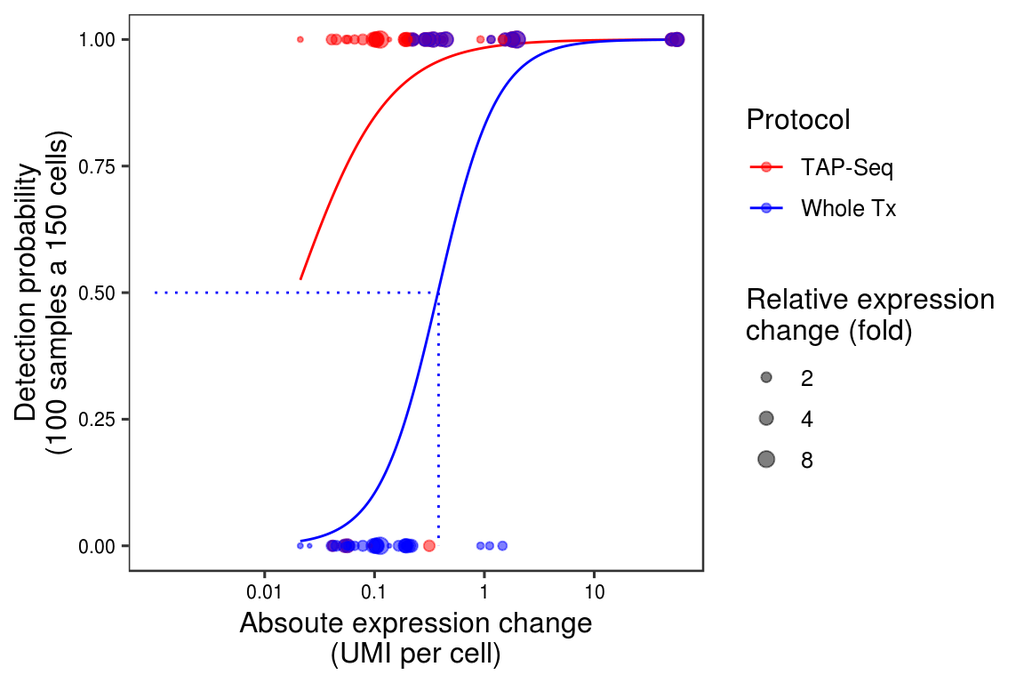

```r
nr <- 1000; nc <- 150
yint <- glm.singlenumber$fifty[glm.singlenumber$assay == "WholeTx" & glm.singlenumber$ncells == nc & glm.singlenumber$reads == nr]
segplf <- data.frame(x = c(-3, yint),
                     xend = c(yint,yint),
                     y = c(0.5,0.5),
                     yend = c(0.5,0))

factor <- 1
#pdf("/g/steinmetz/project/singcellTxn/CRISPRdrop/LV/Revisions/ReplaceFigures/002_illustrateSensitivity.pdf",width=4.5,height=2.1)
ggplot(aes(x = x - log10(factor), y =y), geom="line", data= subset(glmodels, ncells ==nc& reads == nr)) + geom_line(aes(color=assay, group =assay)) +
  theme_bw(base_size=12) + theme(panel.grid = element_blank(), axis.text = element_text(color = "black", size = 8)) + xlab("Absoute expression change\n(UMI per cell)") + ylab(sprintf("Detection probability\n(100 samples a %d cells)", nc)) +
  scale_x_continuous(breaks  = seq(-2,3), labels = c(0.01,0.1,1,10,100,1000)) + scale_color_manual(labels = c("TAP" = "TAP-Seq", "WholeTx" = "Whole Tx"), values = c("TAP" = "red", "WholeTx" = "blue"), name = "Protocol") +
  geom_point(aes(x = expr - log10(factor),y = as.numeric(hit),size = expr.rel, color = assay), data=subset(modelfs,  ncells ==nc & reads == nr), alpha =0.5) + scale_size_area(max_size=3, name = "Relative expression\nchange (fold)", breaks = 1:4, labels = 2^(1:4)) +
  geom_segment(aes(x = x - log10(factor), y=y, xend = xend - log10(factor), yend= yend),data=segplf, color = "blue", linetype = 3)
```

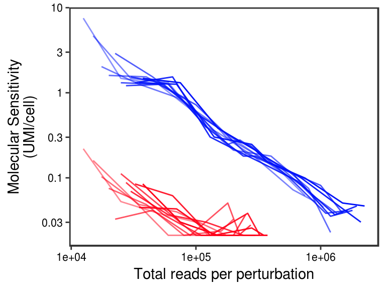

```r
#pdf("/g/steinmetz/project/singcellTxn/CRISPRdrop/LV/Revisions/ReplaceFigures/002_readsVsMolSens.pdf",width=2.8,height=2.1)
qplot(x = reads * ncells, y = fifty - log10(factor) , color =assay ,group = paste(ncells, assay), alpha =ncells, geom="line",data=subset(glm.singlenumber,ncells > 40)) + ylab("Molecular Sensitivity\n(UMI/cell)") + xlab("Total reads per perturbation")  + theme_bw()  + theme(legend.position = "bottom") + scale_x_log10()+  scale_color_manual(name ="Method",values = c("TAP"= "#ff0018","WholeTx" = "#0012f9", "WholeGenome" = "#555555"), guide=F) +  theme(panel.grid = element_blank(), panel.border = element_rect(fill=NA, size=1),axis.text = element_text(colour = "black", size=8)) + scale_alpha_continuous(range = c(0.25,1),limits=c(10,150),guide=F) + scale_y_continuous(breaks  = log10(c(0.03,0.1,0.3,1,3,10,30,100,300,1000,3000)), labels = c(0.03,0.1,0.3,1,3,10,30,100,300, 1000,3000))
```

```r
#dev.off()
```

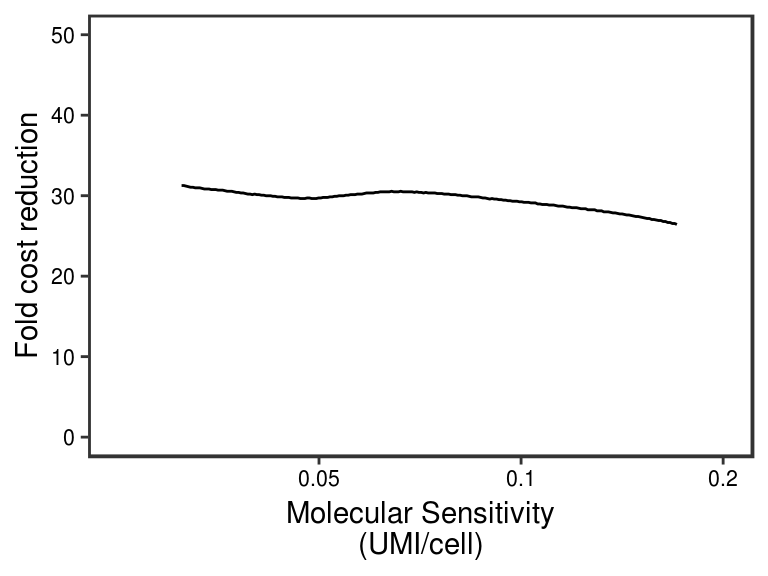

```r
glm.singlenumber$totalreads <- glm.singlenumber$reads * glm.singlenumber$ncells

fit.tap <- loess(fifty ~ log10(totalreads), data= subset(glm.singlenumber,  assay == "TAP" & ncells > 40))
fit.whole <- loess(fifty ~ log10(totalreads), data= subset(glm.singlenumber,  assay == "WholeTx"& ncells > 40))
range <- 10^seq(3,6.5,by=0.001)
sensrange <- seq(min(glm.singlenumber$fifty, na.rm = T),max(glm.singlenumber$fifty, na.rm=T),length.out = 1000)
lookup <- data.frame(reads = range,
                     sens.tap = predict(fit.tap, newdata = data.frame(totalreads = range)),
                     sens.whole = predict(fit.whole, newdata = data.frame(totalreads = range)))
cost <-data.frame(sens = sensrange,
                  reads.tap = sapply(sensrange, function(x) if (min(abs(lookup$sens.tap - x),na.rm = T) < 0.002) lookup$reads[which.min(abs(lookup$sens.tap - x))] else NA),
                  reads.whole = sapply(sensrange, function(x) if (min(abs(lookup$sens.whole - x),na.rm = T) < 0.002)  lookup$reads[which.min(abs(lookup$sens.whole - x))] else NA))
cost$savings <- cost$reads.whole / cost$reads.tap

#pdf("/g/steinmetz/project/singcellTxn/CRISPRdrop/LV/Revisions/ReplaceFigures/002_costMolecular.pdf",width=2.1,height=2.1)
qplot(x  = sens - log10(factor), y = savings, data= cost, geom="line") + xlab("Molecular Sensitivity\n(UMI/cell)") + ylab("Fold cost reduction") + theme_bw() + theme(panel.grid = element_blank(), panel.border = element_rect(fill =NA, size=1), axis.text = element_text(size=8, color = "black")) + scale_y_continuous(limits=c(0,50), breaks = seq(0,50,by=10)) + scale_x_continuous(limits= c(-1.6,log10(0.2)), breaks  = log10(c(0.02,0.05,0.1,0.2)), labels = c(0.02,0.05,0.1,0.2))
```

```r
#dev.off()
```